# Supplemental Materials: Polymethylation Scores for Prenatal Maternal Smoke Exposure Persist Until Age 15 and Are Detected in Saliva

# Supplemental Figure 8 - Associations between prenatal maternal smoking and other *a priori* CpG sites selected from previous meta-analyses among 811 children in the Fragile Families and Child Wellbeing study

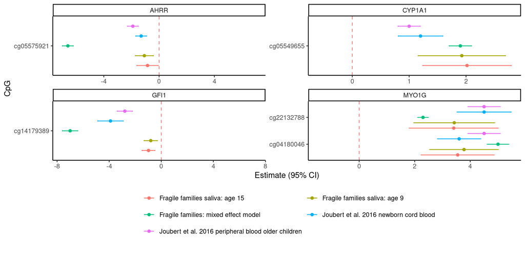

# Supplemental Table 6: Area under the curve for models shown in Main Figure 4 for classifying prenatal maternal smoke exposure, with *P* value when comparing to base model only or to model using polymethylation score + base model. Base model: Child sex, maternal income to poverty ratio, immune cell proportion, plate, 1st two principal components from PCA on child genetic data, child age.

| Age | Model | AUC | P value vs base model | P value vs base model + polymethylation score |
| --- | --- | --- | --- | --- |
| Age 9 | Global methylation | 0.54 | 0.0000 | 0.0000 |
| Age 9 | Sustained smoking polymethylation score (newborns, cell-type controlled) | 0.67 | 0.0560 | 0.0000 |
| Age 9 | AHRR: cg05575921 | 0.55 | 0.0000 | 0.0000 |
| Age 9 | Base model+No methylation | 0.73 | 1.0000 | 0.0003 |
| Age 9 | Base model+Global methylation | 0.73 | 0.5607 | 0.0003 |
| Age 9 | Base model+Sustained smoking polymethylation score (newborns, cell-type controlled) | 0.77 | 0.0003 | 1.0000 |
| Age 9 | Base model+AHRR: cg05575921 | 0.74 | 0.1328 | 0.0334 |
| Age 15 | Global methylation | 0.53 | 0.0000 | 0.0000 |
| Age 15 | Sustained smoking polymethylation score (newborns, cell-type controlled) | 0.65 | 0.0271 | 0.0000 |
| Age 15 | AHRR: cg05575921 | 0.54 | 0.0000 | 0.0000 |
| Age 15 | Base model+No methylation | 0.72 | 1.0000 | 0.0009 |
| Age 15 | Base model+Global methylation | 0.72 | 0.3802 | 0.0010 |
| Age 15 | Base model+Sustained smoking polymethylation score (newborns, cell-type controlled) | 0.77 | 0.0009 | 1.0000 |
| Age 15 | Base model+AHRR: cg05575921 | 0.73 | 0.4054 | 0.0071 |

# Supplemental Table 7: Area under the curve when using different coefficient sets to construct polymethylation scores for predicting prenatal maternal smoke exposure. With *P* value when comparing to base model only or to model using polymethylation score + base model. Base model: Child sex, maternal income to poverty ratio, immune cell proportion, plate, 1st two principal components from PCA on child genetic data, child age.

| Age | Model | AUC | P value vs base model | P value vs base model + polymethylation score with cell-type control |
| --- | --- | --- | --- | --- |
| Age 9 | Any smoking polymethylation score (newborns) | 0.6215 | 0.0012 | 0.0000 |
| Age 9 | Sustained smoking polymethylation score (newborns, cell-type controlled) | 0.6658 | 0.0560 | 0.0000 |
| Age 9 | Sustained smoking polymethylation score (newborns) | 0.6196 | 0.0010 | 0.0000 |
| Age 9 | Sustained smoking polymethylation score (older children) | 0.6341 | 0.0040 | 0.0000 |
| Age 9 | Base model+No methylation | 0.7252 | 1.0000 | 0.0003 |
| Age 9 | Base model+Any smoking polymethylation score (newborns) | 0.7598 | 0.0027 | 0.0142 |
| Age 9 | Base model+Sustained smoking polymethylation score (newborns, cell-type controlled) | 0.7737 | 0.0003 | 1.0000 |
| Age 9 | Base model+Sustained smoking polymethylation score (newborns) | 0.7596 | 0.0027 | 0.0125 |
| Age 9 | Base model+Sustained smoking polymethylation score (older children) | 0.7666 | 0.0007 | 0.4181 |
| Age 15 | Any smoking polymethylation score (newborns) | 0.6062 | 0.0007 | 0.0000 |
| Age 15 | Sustained smoking polymethylation score (newborns, cell-type controlled) | 0.6473 | 0.0271 | 0.0000 |
| Age 15 | Sustained smoking polymethylation score (newborns) | 0.6056 | 0.0006 | 0.0000 |
| Age 15 | Sustained smoking polymethylation score (older children) | 0.5923 | 0.0002 | 0.0000 |
| Age 15 | Base model+No methylation | 0.7213 | 1.0000 | 0.0009 |
| Age 15 | Base model+Any smoking polymethylation score (newborns) | 0.7566 | 0.0011 | 0.1124 |
| Age 15 | Base model+Sustained smoking polymethylation score (newborns, cell-type controlled) | 0.7664 | 0.0009 | 1.0000 |
| Age 15 | Base model+Sustained smoking polymethylation score (newborns) | 0.7569 | 0.0011 | 0.1270 |
| Age 15 | Base model+Sustained smoking polymethylation score (older children) | 0.7530 | 0.0075 | 0.1071 |